# Homewok 1

Dr. Isuru Dassanayake

Instructions: Include all **codes** and **R-outputs** that are **necessary** for each question.

Submission: You **MUST** submit a PDF file only.

#### Question 1:

The data sets here consists of applications for admission to graduate study at the University of California, Berkeley for the Fall 1973. “Admission.csv” contains university level admission status and “Original_Admissions_Data.csv” contains admissions by each department.

1. Using GGplot create an appropriate graphic to show the university-level Admissions. (Hint: Female and male applications admitted and rejected (stacked bar plot (2 bars), admitted and rejected broken down by % male/female.) (Use Admissions.csv).
2. Assume admissions are conducted at the department level. Create an appropriate graphic to show the department level Admissions. (use Original_Admissions_Data.csv). (Hint: Let’s look at %male/female for admitted and rejected applicants by department.)
3. Are admissions gender biased? What other factors could influence admission rates? Discuss.

#### Question 2:

The data set used, represents gene expression data for multiple samples. Use `gene expression.csv` for this question.

1. Create a scatter plot representing gene expression of “sampleB” on the X-axis and “sampleH” on the Y-axis. What kind of relationship do you observe?
2. Add a column to the data frame, according to the following conditions:
   - Name the new column as “expre_limit”.
   - If the expression of a gene is > 13 in both sampleB and sampleH, set to the value in “expre_limits” to “high”.
   - If the expression of a gene is < 6 in both sampleB and sampleH, set it to “low”.
   - If different, set it to “normal”.
3. Color the points of the scatter plot according to the newly created column “expre_limits”. Save that plot in the object “plot1”.
4. Rename the legend title as “Expression Limits”.
5. Add another layer to “plot1” in order to change the points colors to blue (for low), grey (for normal) and red (for high). Save this plot in the object “plot2”.
6. Produce a bar plot of how many low/normal/high genes are in the column ‘expre_limits’. Save this plot as “plot3”.
7. To plot3, add an horizontal line at “counts = 250”.
8. Swap the X-axis and the Y-axis of the plot from part 7).

#### Question 3:

Titanic data set from `Kaggle.com` is used for this example. Please use `titanic.csv` for this question.

Description of the data set as follows:

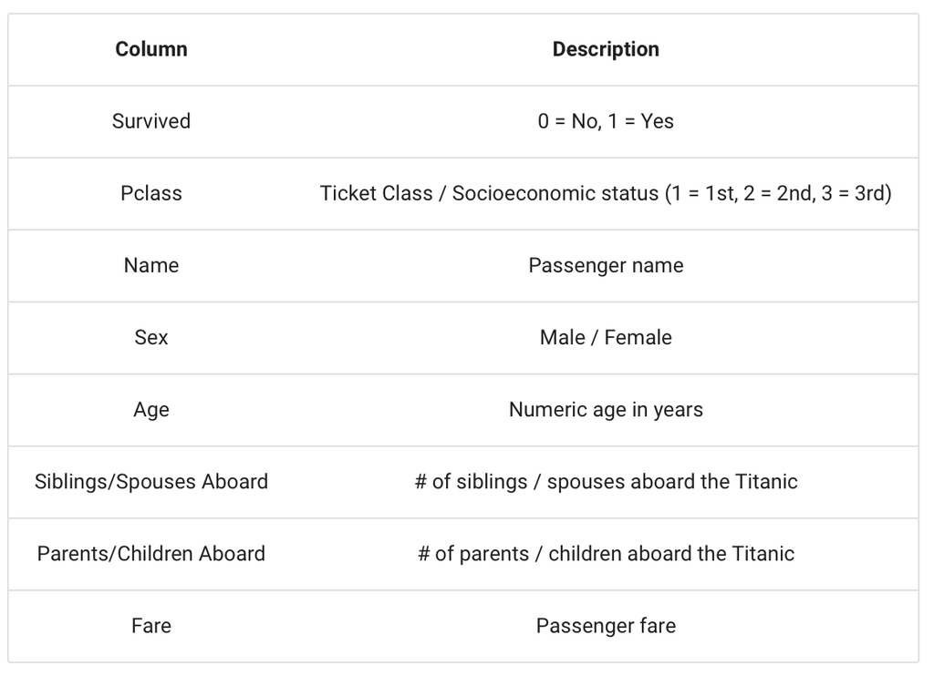

1. Is there a relationship between the age of the passenger and the passenger fare? Explore this by constructing a scatter plot.
2. Color the points from question 1 by Pclass. Remember that Pclass is a proxy for socioeconomic status.
3. Manually scale the colors in question 4. 1st class = red, 2nd class = purple, 3rd class = seagreen. Also change the legend labels (1 = 1st Class, 2 = 2nd Class, 3 = 3rd Class).
4. Create Juxtaposed plots for the scatter plot made in 3 by the column ‘Sex’
5. Plot the number of passengers (a simple count) that survived by ticket class.